# Forecasting Popular Vote in 2023 Federal Elections with MRP

STA304 - Academic Project

Dhruv Goyal

May 28, 2021

## Introduction

The year 2021 is closing in on halfway and soon enough we will see 2022. That leaves 1 year 10 months and 16 days till the next Canadian federal election. The next federal election will decide the House of Commons to the 44th Canadian Parliament. The House of Commons comprises of multiple political parties, but the ones that take center stage are The Liberal Party, The Conservative Party, Bloc Québécois, The New Democratic and The Green Party. Through this paper we try to predict the overall popular vote of the 2023 Canadian federal elections.

The importance of forecasting Canadian federal elections has been relevant throughout history. The party that forms the federal government represents the voice, concerns and values of Canadians for the next 4 years. Prediction analysis allows political parties to understand, plan and develop strategies that popularize their values, beliefs and ideas of implementing and running the country. It provides an insight into voting patterns observed by province, age, income etc. and other demographics of Canadians who are eligible to vote. Predication analysis further gives an insight into ethical, social and economical changes and beliefs that align with the general Canadian population and thus the most popular party of their choice. It allows Canadians to exercise their right to vote and demand for change upon reflecting the decisions, policies and welfare acts of the past federal government, such as evaluating government response and strategies during the COVID-19 pandemic. This paper focuses on predicting the most popular party of choice, and in doing so, it determines the morals, codes and beliefs of the 27 million Canadians who are eligible to vote[1].

This paper predicts the overall popular vote of the 2023 federal elections using a Multilevel Logistic Regression Model with Post-stratification. The Multilevel Logistic Regression model is built from ‘Canadian Election Study, 2019, Phone Survey’ data (CES_2019 data) which analysis responses of Canadian to question related to their preferred political party and also gathers demographic information(such as age, sex, occupation etc.) of the respondents. Post-stratification is done using the General Social Survey(GSS) Data found at University of Toronto’s CHASS data repository. Furthermore, this paper recognizes and justifies age, education, income level and province as meaningful predictors to the popular party of choice of eligible Canadians using the CES_2019 survey data which is post-stratified to the general voter population. Therefore, research question of this paper is focused on forecasting the overall popular vote for the next federal election based on the age, education, income of a voter in each province, for the six aforementioned political party’s. We hypothesize that due to the popularity of The Liberal Party in Canada and the fact that they formed government in the 2015, 2019 federal elections [2], most provinces will be dominated by it, however some provinces may also see a neck-to-neck competition between the Conservative Party and the Liberal party which has seen an upward trend in its following, especially in the past two elections [2].

$\\$

$\\$

## Data

### Data Description

The CES_2019 survey data contains about 4021 rows and 278 variables. It is an annual survey, with data being collected between 2019-09-10 and 2019-11-21. It targets Canadian Citizens and Permanent Residents over 18 years compiling a rich set of data about Canadians’ demographics, opinions and thought process on a wide variety of social, economic, and political issues.

The GSS dataset corresponds to the census dataset used in this research paper. It contains 20602 observations and 81 variables. The target population includes all non-institutionalized persons 15 years of age and older, currently residing in the 10 provinces of Canada. This survey was conducted from February 2nd to November 30th, 2017.[3] It uses telephone numbers registered with Statistics Canada’s Address Register to primarily collect demographic information on the target population through telephonic means. It is important to note that this dataset does not include any information about an individuals political preferences, but rather, it focuses on collecting information related to the demographic attributes of individuals.

### Data Cleaning

The Survey data and Census data, both needed to be cleaned to identify important variables and run the prediction analysis.

The statistical language `R version 4.0.2` was used to clean and analyze the data. Important packages include : *tidyverse, ggplot and dplyr*. Important functions include *select()*, which allows selection/deselection of variables in an r data frame, *mutate()* which allows to create new coloumns by manipulating existing columns, *filter()* which filters column values based on specified conditions and *rename()* which renames a coloumn/variables name. Since the paper implements post-stratification, the process of data cleaning included - selecting chosen variables from the 2 datasets and then matching variables within the two datasets similar variables have the same levels/categories/bins. To implement this, *case_when()* function was used to specify, change and match variables between the two datasets.

Important variables chosen from the survey data that are also present in the census data include

- Popular_party : The name of the respondents preferred party.
- Age : Age of the respondent
- Education : level of education of the respondent
- Income : Household/personal income of the respondent
- Province : Province of residence of the respondent.

Data Cleaning also includes dealing with missing data from the two datasets. The following snippet shows the missing values in the survey data followed by the missing values in the census data.

```
## popular_party           age      province     education income_family
##             0            57             0             0             0
```

```
##           age      province     education income_family
##           965             0           341             0
```

After implementing the above mentioned procedures, a glimpse of the survey data and the census data are provided below.

```r
head(survey_data)
```

|  | popular_party | age | province | education | income_family |
| --- | --- | --- | --- | --- | --- |
| 1 | The Liberal party | ages50to64 | Quebec | Bachelor's degree (e.g. B.A., B.Sc., LL.B.) | $100,000 to $ 124,999 |
| 2 | The Conservative party | age35to49 | Quebec | University certificate or diploma below the bachelor's level | $75,000 to $99,999 |
| 3 | The Liberal party | ages20to34 | Quebec | Bachelor's degree (e.g. B.A., B.Sc., LL.B.) | Less than $25,000 |
| 4 | The Liberal party | ages20to34 | Quebec | University certificate or diploma below the bachelor's level | $100,000 to $ 124,999 |
| 5 | The Liberal party | age35to49 | Quebec | University certificate, diploma or degree above the bach... | $75,000 to $99,999 |
| 6 | The Conservative party | ages75to90 | Quebec | High school diploma or a high school equivalency certificate | $25,000 to $49,999 |

```r
head(census_data)
```

| age | education | income_family | province |
| --- | --- | --- | --- |
| ages50to64 | High school diploma or a high school equivalency certificate | $25,000 to $49,999 | Quebec |
| ages50to64 | Trade certificate or diploma | $75,000 to $99,999 | Manitoba |
| ages50to64 | Bachelor's degree (e.g. B.A., B.Sc., LL.B.) | $75,000 to $99,999 | Ontario |
| ages75to90 | High school diploma or a high school equivalency certificate | $100,000 to $ 124,999 | Alberta |
| ages20to34 | College, CEGEP or other non-university certificate or di... | $50,000 to $74,999 | Quebec |
| ages50to64 | High school diploma or a high school equivalency certificate | $50,000 to $74,999 | Quebec |

This paper primarily focuses on analyzing the popular vote of the 6 Political parties including The Liberal Party, Conservative Party, NDP, Bloc Quebecois, Green Party and The Peoples’ Party. The survey data however, contains information about all the party’s in a single column - *popular_party*. To proceed with our analysis, we created 6 different iterations of the survey data called *survey_data_liberal*, *survey_data_conservative*, *survey_data_ndp*, *survey_data_bloc*, *survey_data_green* and *survey_data_peoples*. Every iteration had the same information as the original survey data but with the *popular_party* column was modified. For example, the *survey_data_liberal* dataframe created a new variable *vote_liberal* that marked “1” if an individual thinks the liberal party is the most popular and thus has a chance to win, “0” if the individual is not sided with the liberal party or if they skipped/refused to reply to the respective survey question.

As an example to the above procedure, we show a glimpse of *survey_data_liberal*:

```r
head(survey_data_liberal)
```

|  | age | province | education | income_family | vote_liberal |
| --- | --- | --- | --- | --- | --- |
| 1 | ages50to64 | Quebec | Bachelor's degree (e.g. B.A., B.Sc., LL.B.) | $100,000 to $ 124,999 | 1 |
| 2 | age35to49 | Quebec | University certificate or diploma below the bachelor's level | $75,000 to $99,999 | 0 |
| 3 | ages20to34 | Quebec | Bachelor's degree (e.g. B.A., B.Sc., LL.B.) | Less than $25,000 | 1 |
| 4 | ages20to34 | Quebec | University certificate or diploma below the bachelor's level | $100,000 to $ 124,999 | 1 |
| 5 | age35to49 | Quebec | University certificate, diploma or degree above the bach... | $75,000 to $99,999 | 1 |
| 6 | ages75to90 | Quebec | High school diploma or a high school equivalency certificate | $25,000 to $49,999 | 0 |

$\\$

$\\$

$\\$

$\\$

### Data analysis

To further understand the importance of our analysis, we present some summary statistics. These summary statistics dive into the reason behind using age, education and income in our paper.

### Analysis of Age

| age | liberal_votes | Conservative_votes | ndp_votes | Bloc_votes | Green_votes | Peoples_votes |
| --- | --- | --- | --- | --- | --- | --- |
| age35to49 | 577 | 335 | 34 | 0 | 5 | 1 |
| ages20to34 | 339 | 219 | 36 | 1 | 7 | 2 |
| ages50to64 | 609 | 396 | 21 | 2 | 1 | 2 |
| ages65to74 | 353 | 216 | 4 | 1 | 4 | 1 |
| ages75to90 | 213 | 133 | 3 | 1 | 2 | 2 |
| ages90to102 | 13 | 6 | 0 | 0 | 1 | 0 |

The above chunk provides an insight into the importance of age vs the party of choice and is modeled from the survey data. It groups age and sums the votes given by each category of age to different partys’. The liberal party and the conservative party have the most votes in every age category compared to other parties.

### Analysis of Education

| education | liberal_votes | Conservative_votes | ndp_votes | Bloc_votes | Green_votes | Peoples_votes |
| --- | --- | --- | --- | --- | --- | --- |
| Bachelor's degree (e.g. B.A., B.Sc., LL.B.) | 657 | 307 | 16 | 0 | 0 | 1 |
| College, CEGEP or other non-university certificate or di... | 106 | 96 | 7 | 0 | 2 | 1 |
| Don't know | 2 | 2 | 2 | 0 | 1 | 1 |
| High school diploma or a high school equivalency certificate | 312 | 283 | 28 | 3 | 8 | 2 |
| Less than high school diploma or its equivalent | 31 | 22 | 4 | 1 | 1 | 0 |
| Refusal | 1 | 0 | 0 | 0 | 0 | 0 |
| Trade certificate or diploma | 387 | 347 | 24 | 1 | 6 | 2 |
| University certificate or diploma below the bachelor's level | 178 | 115 | 13 | 0 | 2 | 1 |
| University certificate, diploma or degree above the bach... | 430 | 133 | 4 | 0 | 0 | 0 |

### Analysis of Income

| income_family | liberal_votes | Conservative_votes | ndp_votes | Bloc_votes | Green_votes | Peoples_votes |
| --- | --- | --- | --- | --- | --- | --- |
| $100,000 to $ 124,999 | 222 | 126 | 9 | 0 | 0 | 0 |
| $125,000 and more | 511 | 300 | 17 | 0 | 1 | 2 |
| $25,000 to $49,999 | 235 | 153 | 11 | 0 | 6 | 0 |
| $50,000 to $74,999 | 285 | 203 | 9 | 0 | 2 | 0 |
| $75,000 to $99,999 | 231 | 132 | 9 | 0 | 1 | 1 |
| Don't know | 173 | 109 | 19 | 1 | 5 | 2 |
| Less than $25,000 | 180 | 101 | 17 | 4 | 5 | 2 |
| Refusal | 267 | 181 | 7 | 0 | 0 | 1 |

The above chunk provides an insight into the importance of income vs the party of choice and is modeled from the survey data again. It groups income and sums the votes given by each category of the income variable to different partys’. Yet again, the liberal party and the conservative party have the most votes in every category of the income variable compared to other parties.

## Methods

### Model Specifics

The goal of this research paper is to predict the popular vote of the upcoming 2023 federal elections by province using a multilevel logistic regression model with post-stratification.

The independent variables *age*, *income*, *education* and *province* were selected to create multilevel logistic regression model since a paper posted by Statistics Canada [5] suggests that these variable affect voter turn out rates as well as reflect a persons beliefs, ethics and morals which conclusively reflects their political preferences and expectation towards a party.

To the create the multilevel logistic regression model we will be using age, income, education and province as independent variables which will predict the popular vote. The independent variables province will be used as a group level variable that will model the intercepts of models with respect to different provinces.

The data used for this analysis is the cleaned survey data which is further modified into *survey_data_liberal*, *survey_data_conservative*, *survey_data_ndp*, *survey_data_bloc*, *survey_data_green* and *survey_data_liberals*. This means we have 6 different models that use the same independent and dependent variables but are made from different datasets. To be precise, we use :

- A model to predict whether an individual votes for the liberal party based on their age, education, income and province made using *survey_data_liberal*, with dependent variable *vote_liberal*.
- A model which predicts whether an individual votes for the conservative party based on the same variables but made using *survey_data_conservative*, with dependent variable *vote_conservative*.
- A model which predicts whether an individual votes for the NDP party based on the same variables but made using *survey_data_ndp*, with dependent variable *vote_ndp*
- A model which predicts whether an individual votes for the Bloc Quebecois party based on the same variables but made using *survey_data_bloc*, with dependent variable *vote_bloc*.
- A model which predicts whether an individual votes for the Green party based on the same variables but made using *survey_data_green*, with dependent variable *vote_green*.
- A model which predicts whether an individual votes for the Peoples party based on the same variables but is made using *survey_data_peoples*, with dependent variable *vote_peoples*.

Since each model uses the same independent variables, the general form of multilevel logistic regression model is given by:

$y = \beta_1 x_{age} + \beta_2 x_{education} + \beta_3 x_{income} + \beta_4 x_{1|province} + \epsilon$

Where,

- $y$ represents the log odds of one of the dependent variable : *vote_liberal*, *vote_conservative*, *vote_ndp*, *vote_bloc*, *vote_green*, *vote_peoples*.
- $\beta_0$ represents the intercept of the model
- $\beta_1$ represents the coefficient for age
- $\beta_2$ represents the coefficient for education
- $\beta_3$ represents the coefficient for income
- $\beta_4$ represents the coefficient for group variable province
- $\epsilon$ represents the error in the model

### Post-Stratification

In order to estimate the popular vote of each province, we use the statistical technique of post stratification. Under this technique, the census dataset is split into mutually exclusive bins based on demographics of the population. Then we estimate a response or quantity of interest for each cell. This is followed by aggregating the cell-level estimates up to a population-level estimate by weighting each cell by its relative proportion in the population or the census data. Post-stratification is particularly useful since it allows us to adjust non-representative samples to better analyze opinions and other survey responses.

The following formula is used for post-stratification: $\hat{y}^{PS} = \frac{\sum{N_j \cdot \hat{y_j}}}{\sum{N_j}}$

- $\hat{y}^{PS}$ is the estimate in each cell after weighting it by its relative portion.
- $\sum{N_j}$ is the population size of the $j^{th}$ cell based off demographics.

To fulfill the purpose of this paper, we use age, education, income and province as demographic variables. We create bins splits using different levels of age, education, income and province in the census data. This means each cell is mutually exclusive and only includes those individuals that belong to a single category of age, a single category of education, a single category income and a province (Categories of each of these variables is described in the data section). Next, we estimate $N_j$ by summing the number of individuals in each cell/bin. To estimate the popular vote in each province, we estimate the proportion of those groups of cells/bins that belong a particular province. This is done by dividing each $N_j$ by the sum of all $N_j$ ’s that belong to a particular province. Finally, each of the 6 different models is applied to the post-stratification data to estimate the 6 different $\hat{y}^i$ ’s, which calculates the log odds of the probability of voting for a particular party (depending on the model used). Finally, $\hat{y}^{PS}$ is estimated by taking the product of the $\hat{y}^i$ and the estimated proportion of each cell grouped by province for each model.

## Results

The chunk below gives a glimpse of the population is each strata/bin (given by n()) and the proportion of population in that respective strata/bin (given by prop).

| age | education | income_family | province | n | prop |
| --- | --- | --- | --- | --- | --- |
| ages50to64 | High school diploma or a high school equivalency certificate | $25,000 to $49,999 | Quebec | 63 | 0.017563423 |
| ages50to64 | High school diploma or a high school equivalency certificate | $25,000 to $49,999 | Manitoba | 11 | 0.009874327 |
| ages50to64 | High school diploma or a high school equivalency certificate | $25,000 to $49,999 | Ontario | 63 | 0.011990864 |
| ages50to64 | High school diploma or a high school equivalency certificate | $25,000 to $49,999 | Alberta | 26 | 0.016069221 |
| ages50to64 | High school diploma or a high school equivalency certificate | $25,000 to $49,999 | Nova Scotia | 23 | 0.016936672 |
| ages50to64 | High school diploma or a high school equivalency certificate | $25,000 to $49,999 | British Columbia | 29 | 0.012272535 |

The chunk below gives the mean proportion of votes from the population for a particular party grouped by province.

| province | mean_liberal | mean_conservative | mean_ndp | mean_bloc | mean_greens | mean_peoples |
| --- | --- | --- | --- | --- | --- | --- |
| Quebec | 0.6038197 | 0.2494097 | 0.02639856 | 1.478264e-02 | 0.003729321 | 0.001484787 |
| Manitoba | 0.3998034 | 0.4458800 | 0.03120806 | 1.086123e-05 | 0.007042200 | 0.001666070 |
| Ontario | 0.5100765 | 0.3338298 | 0.02829774 | 6.403839e-06 | 0.005969671 | 0.001755853 |
| Alberta | 0.3776083 | 0.5210658 | 0.02317276 | 6.477884e-06 | 0.003239657 | 0.001968420 |
| Nova Scotia | 0.5383714 | 0.3116003 | 0.02550249 | 9.666869e-06 | 0.006793070 | 0.001565529 |
| British Columbia | 0.4850694 | 0.3452607 | 0.03262111 | 7.171237e-06 | 0.011466535 | 0.001922340 |

The following is a plot of the results obtained above:

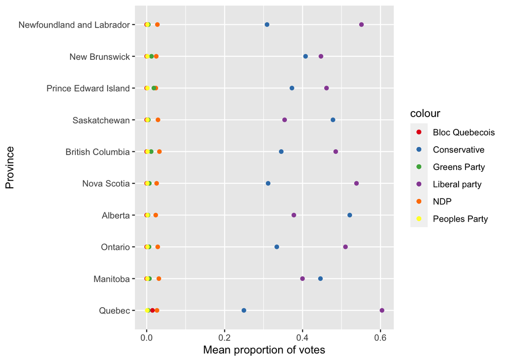

## Conclusions

### Present and Future Outlook:

In a democracy, the people are the ones making the vote and campaigning is an essential momentum builder for each candidate. However, we are amid the pandemic and Elections Canada is closely monitoring its evolving impact. Alternative plans of operation are being developed so that an election can be delivered during unforeseen circumstances. This could possibly change the history of how federal elections were conducted in Canada and how they should be for the future if proved successful. For this reason, we can see some of the bigger and more popular parties are gearing up for a long season of elections. Approach to campaigning might not be very conventional this time around but there has been noise at the House of Commons on a possible election this year. (Ljunggren, 2021) However, this is unsure and for such reasons Parties are working on raising funds early on and looking for nominations while being stranded in their pajamas from home because Canada has had a very slow progress in combatting the pandemic. With this uncertainty lies varied goals of each party. The Liberal party is aiming for a majority rule, the Conservatives will be happy with any scenario in which they can move across the aisle of the House of Commons to the government benches. The NDP on the other hand, is looking to knock Bloc Québécois from third spot and the Bloc are looking to cement their third position spot because they know that they can never win Government. Lastly, the Green Party have only three seats in a legislature whereas you need twelve to be recognized as an official party. (Reynolds, 2021)

Using multi-level logistic regression model with post-stratification we were able to get an insight into the next Federal elections in Canada. As mentioned in the introduction this information and analysis not only relevant to disparate political party’s but also reflect the ethics, morals and beliefs of the Canadian Population who are eligible to vote. The prevalence and influence of the Liberal Party is mirrored in our analyses while also reflecting upon the growing influence on the Conservative parties along with parties.

## Bibliography

1. Mapleleafweb.com. 2021. Voter Turnout in Canada | Mapleleafweb.com. [online] Available at: http://www.mapleleafweb.com/features/voter-turnout-canada [Accessed 28 May 2021].
2. En.wikipedia.org. 2021. 2019 Canadian federal election - Wikipedia. [online] Available at: https://en.wikipedia.org/wiki/2019_Canadian_federal_election [Accessed 28 May 2021].
3. https://sda-artsci-utoronto-ca.myaccess.library.utoronto.ca/sdaweb/dli2/gss/gss31/gss31/more_doc/GSS31_User_Guide.pdf
4. 2019 Canadian federal election - [online] Available at: https://en.wikipedia.org/wiki/2019_Canadian_federal_election [Accessed 28 May 2021].